# The `anova_*` functions

What they do, and the thinking behind them

Author

Ryan Dobson

Published

September 4, 2026

## The idea in three sentences

A complete, defensible one-way ANOVA takes a page of code: descriptives, two or three assumption checks, the test, an effect size, group means with the right standard error, a figure, and a sentence. Most of that page is the same every time, and the parts that vary are decisions you should be making deliberately rather than retyping.

These functions do the routine parts in one line each, and make the decisions visible: **what you should do next depends on what the assumption checks found**, so the checks are a separate step that ends in a recommendation with a citation attached.

Everything below runs on `PlantGrowth`, which ships with R, so anything here can be pasted and run.

## Assumptions first, and separately

This is the design decision everything else follows from.

Assumption checking is not a formality you complete before the “real” analysis. It *determines* which analysis is the right one. So it is its own function, and it ends by telling you what to run.

```r
fit <- aov(weight ~ group, data = PlantGrowth)
anova_check(fit)
```

```
#>
#> Assumption checks: weight ~ group
#> =================================
#>
#>   30 observations, 3 groups (10 / 10 / 10), balanced
#>
#>   Normality of residuals       W = 0.966, p = .438              OK
#>   Homogeneity of variance      F(2, 27) = 1.24, p = .306        OK
#>       largest / smallest group variance = 3.22
#>   Independence of observations                                  not testable
#>       a property of the design, not of the data; check that no observation
#>       could have influenced another
#>
#> ---------------------------------
#>
#>   RECOMMENDED NEXT STEP
#>
#>     Proceed with the standard one-way ANOVA: aov(y ~ group, data = d)
#>
#>       Nothing in the testable assumptions is flagged. Independence remains
#>       a design question rather than something the data can confirm.
#>
#>     See: model_comparison, ms_within
#>     anova_ref("model_comparison") for the citation and reasoning
#>
#>   anova_check_plots() for the Q-Q, residual histogram, and boxplot.
```

Three things to notice.

**Normality is tested on the residuals, not the raw scores.** The raw values pool three groups with different means, so they can look non-normal when every group is perfectly normal. This is the single most common error in student work, and it is not something you should have to remember.

**Independence is reported as “not testable” rather than passing.** It is a property of how the study was run. No test can confirm it, so the function does not pretend otherwise.

**The output ends with a recommendation, not a verdict.** Which brings us to the point.

### The recommendation changes with the data

Same one line of code. Different data. Different advice.

```r
# unequal variances AND unequal n: the case that actually distorts F
set.seed(11)
d <- data.frame(
  g = factor(rep(c("a", "b", "c"), times = c(30, 10, 10))),
  y = c(rnorm(30, 10, 1), rnorm(10, 11, 6), rnorm(10, 12, 6))
)
print(anova_check(y ~ g, data = d), verbosity = "short")
```

```
#>
#> Assumption checks: y ~ g
#> ========================
#>
#>   50 observations, 3 groups (30 / 10 / 10), UNBALANCED
#>
#>   Normality of residuals       W = 0.881, p < .001              VIOLATED
#>   Homogeneity of variance      F(2, 47) = 25.57, p < .001       VIOLATED
#>       largest / smallest group variance = 84.01
#>   Independence of observations                                  not testable
#>       a property of the design, not of the data; check that no observation
#>       could have influenced another
#>
#> ------------------------
#>
#>   RECOMMENDED NEXT STEP
#>
#>     Use Welch's ANOVA: oneway.test(y ~ group, data = d, var.equal = FALSE)
#>
#>   anova_check_plots() for the Q-Q, residual histogram, and boxplot.
```

```r
# skewed residuals in small groups
set.seed(13)
d2 <- data.frame(
  g = factor(rep(c("a", "b", "c"), each = 10)),
  y = c(rexp(10, .2), rexp(10, .2) + 1, rexp(10, .2) + 2)
)
print(anova_check(y ~ g, data = d2), verbosity = "short")
```

```
#>
#> Assumption checks: y ~ g
#> ========================
#>
#>   30 observations, 3 groups (10 / 10 / 10), balanced
#>
#>   Normality of residuals       W = 0.792, p < .001              VIOLATED
#>   Homogeneity of variance      F(2, 27) = 0.05, p = .952        OK
#>       largest / smallest group variance = 2.36
#>   Independence of observations                                  not testable
#>       a property of the design, not of the data; check that no observation
#>       could have influenced another
#>
#> ------------------------
#>
#>   RECOMMENDED NEXT STEP
#>
#>     Fit a robust counterpart and compare: WRS2::t1way(y ~ group, data = d,
#>     tr = 0.2). Agree, report either; disagree, report the robust one
#>
#>   anova_check_plots() for the Q-Q, residual histogram, and boxplot.
```

That second recommendation is deliberately *not* “transform the outcome.” Field and Wilcox (2017) give six reasons transformations are seldom worth it, the sharpest being that transforming changes the hypothesis you are testing. They are also pointed that trimming at 2.5 *SD* and then running OLS is worse than doing nothing, because the *SD* is itself pulled by the outliers, so they get masked, and the standard errors afterwards are wrong at any sample size.

The recommendation rules live in one table rather than being scattered through the tests, so what the package advises can be read, argued with, and changed in one place.

## Every claim carries its citation

Each recommendation names the concepts it rests on. Those are keys into a reference registry, so the reasoning is always one call away.

```r
anova_ref("homogeneity")
```

```
#>
#> Homogeneity of variance
#> -----------------------
#>
#>   Equal population variances across groups. This is what licenses
#>   pooling into a single MS_W (Equation 56). MDK discuss Levene's test
#>   in Chapter 3 and describe it exactly as implemented here: an ANOVA on
#>   the absolute deviations of scores from their group's centre.
#>   Violations matter most when group sizes are also unequal.
#>
#>   MDK: ch. 3
#>
#>   Also:
#>     Levene, H. (1960). Robust tests for equality of variances. In I.
#>     Olkin (Ed.), Contributions to Probability and Statistics (pp.
#>     278-292). Stanford University Press.
#>     Brown, M. B., & Forsythe, A. B. (1974). Robust tests for the
#>     equality of variances. Journal of the American Statistical
#>     Association, 69(346), 364-367.
```

```r
anova_ref("omega_squared")
```

```
#>
#> Omega hat squared, the bias-corrected estimate
#> ----------------------------------------------
#>
#>   omegahat^2 = (SS_effect - df_effect * MS_W) / (SS_total + MS_W)
#>
#>   Corrects the positive bias in R^2. Report this in preference to R^2 /
#>   eta squared. MDK note it can come out negative, in which case the
#>   estimated population proportion is set to zero. See also the adjusted
#>   R^2 of Equation 99, which Maxwell et al. (1981) showed is typically
#>   within .02 of omega hat squared.
#>
#>   MDK: ch. 3, eq. 96
#>
#>   Also:
#>     Lakens, D. (2013). Calculating and reporting effect sizes to
#>     facilitate cumulative science: A practical primer for t-tests and
#>     ANOVAs. Frontiers in Psychology, 4, 863.
```

Equation numbers are from Maxwell, Delaney and Kelly (2017, 3rd ed.), read out of the book rather than remembered. Where an equation number has not been confirmed it is left blank rather than guessed, on the principle that a wrong equation number is worse than a missing one, because a reader cannot tell it is wrong.

```r
anova_refs_todo()
```

```
#> MDK reference entries not yet verified against the book:
#>
#>                 concept chapter equation verified
#>                 df_full       3     <NA>    FALSE
#>                 se_mean       3     <NA>    FALSE
#>            independence       3     <NA>    FALSE
#>              sphericity      11     <NA>    FALSE
#>   sphericity_correction      11     <NA>    FALSE
#>  homogeneity_covariance      13     <NA>    FALSE
#>    multiple_comparisons       5     <NA>    FALSE
#>
#> 7 of 29 entries outstanding.
#> Chapters are topic-to-chapter assignments and are probably right;
#> equation numbers are deliberately blank rather than guessed.
#> Fill them in by editing .anova_refs in R/anova_refs.R.
```

## The analysis

Once the checks say to proceed:

```r
anova_report(fit)
```

```
#>
#> One-way ANOVA: weight ~ group
#>
#>   F(2, 27) = 4.85, p = .016
#>   R^2     = 0.264   (= eta^2; variance accounted for in this sample)
#>   omega^2 = 0.204   (bias-corrected, report this one)
#>
#>   APA: F(2, 27) = 4.85, p = .016, omega-squared = .20
#>
#>   anova_ref("omega_squared") for why omega squared rather than R^2.
```

Two effect sizes, because the distinction matters and is easy to get wrong. $R^2$ (what most of psychology calls $\eta^2$ in this context) describes the sample and is biased upward as an estimate of the population value. $\hat{\omega}^2$ corrects that bias and is the one to report.

$$\hat{\omega}^2 = \frac{SS_{effect} - df_{effect} \cdot MS_W}{SS_{total} + MS_W}$$

## Group means, with the right standard error

```r
anova_means(fit)
```

```
#>   group  n  mean        sd        se   ci_low  ci_high
#> 1  ctrl 10 5.032 0.5830914 0.1971284 4.627526 5.436474
#> 2  trt1 10 4.661 0.7936757 0.1971284 4.256526 5.065474
#> 3  trt2 10 5.526 0.4425733 0.1971284 5.121526 5.930474
```

The standard error is the **model-based** one:

$$SE(\bar{Y_j}) = \sqrt{\frac{MS_W}{n_j}}$$

not each group’s own $s_j/\sqrt{n_j}$. That is the standard error consistent with the *F* test being reported alongside it, so error bars built from it match the model. Because the design is balanced, all three come out equal, which is the model saying it has one variance estimate and equal *n*.

`pooled = FALSE` gives the per-group version, which is what you want when homogeneity is violated.

## The figure

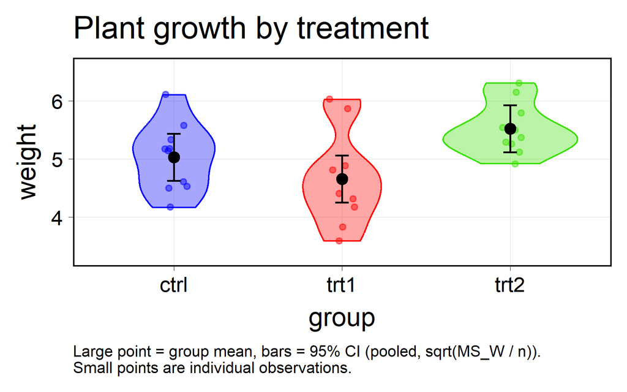

```r
anova_plot(fit, title = "Plant growth by treatment")
```

The message underneath is not decoration. Figures are where quiet decisions get made, so the ones this function made are stated, along with the line of code to change them.

The axis spans the data **and** the confidence intervals plus 10%, rather than zooming tight to the data. A truncated axis exaggerates differences between means. For an outcome with a real measurement scale, say a 1–7 Likert item, pass it and it is used exactly, with every point labelled:

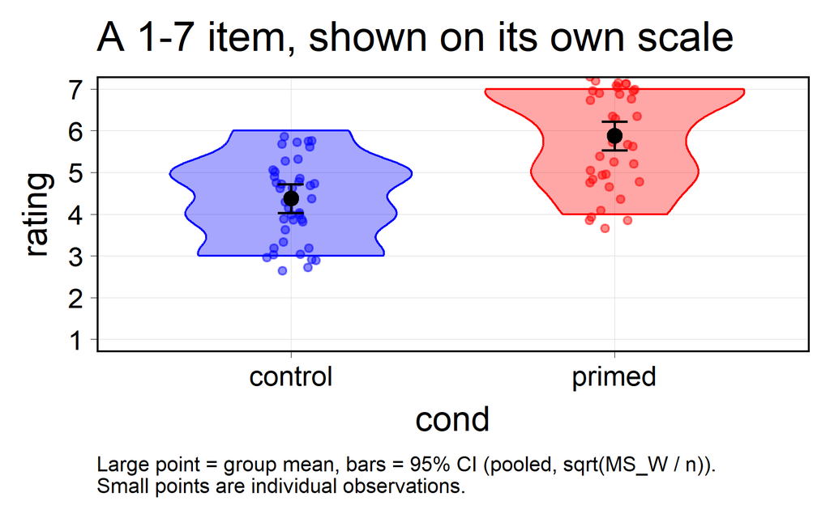

```r
set.seed(5)
lik <- data.frame(
  cond   = factor(rep(c("control", "primed"), each = 40)),
  rating = c(sample(3:6, 40, TRUE), sample(4:7, 40, TRUE))
)
anova_plot(aov(rating ~ cond, data = lik), y_range = c(1, 7),
           title = "A 1-7 item, shown on its own scale", quiet = TRUE)
```

Limits are applied with `coord_cartesian()`, which zooms. The obvious alternative, `scale_y_continuous(limits = )`, silently *drops* observations outside the range, which would change the violin and the intervals rather than just the view of them.

## Does the conclusion survive the decisions you could have made?

Field and Wilcox’s central recommendation is that sensitivity analysis should be routine: fit the conventional model and a robust counterpart, report either where they agree, report the robust one where they do not. Their stronger claim is that this comparison is the only known way to judge whether a conventional method gave a reasonable answer.

`anova_multi()` automates that and widens it, crossing the small analysis decisions you could defensibly have made.

```r
set.seed(8)
sk <- data.frame(
  g = factor(rep(c("ctrl", "trt"), each = 20)),
  y = c(rlnorm(20, 2.0, .85), rlnorm(20, 2.45, .85))
)
mv <- anova_multi(y ~ g, data = sk, contrast = c("trt", "ctrl"))
mv
```

```
#>
#> Mini-multiverse: y ~ g
#> ======================
#>
#>   Focal contrast: trt vs ctrl, standardized
#>   9 specifications (0 could not be fitted)
#>
#>   specification                 d        p omnibus p   effect CI vs base
#>   ---------------------------------------------------------------------
#>   none / pooled / ols        0.86   = .010    = .010    0.138   1.00x
#>   log / pooled / ols         0.84   = .012    = .012    0.130   1.00x
#>   sqrt / pooled / ols        0.88   = .008    = .008    0.146   1.00x
#>   none / welch / ols         0.86   = .011    = .011    0.138   1.02x
#>   log / welch / ols          0.84   = .012    = .012    0.130   1.00x
#>   sqrt / welch / ols         0.88   = .009    = .009    0.146   1.01x
#>   none / robust / trim20     0.74   = .051    = .051    0.565   1.17x *
#>   log / robust / trim20      0.91   = .017    = .017    0.561   1.13x
#>   sqrt / robust / trim20     0.84   = .028    = .028    0.564   1.15x
#>
#>   * marks the 1 specification(s) that disagree with the baseline on
#>   significance. Field and Wilcox: where models deviate, report the robust
#>   one unless there is an evidence-based case that the assumptions were met.
#>   Do not pick the one you liked.
#>
#>   NOTE: effect is omega^2 for OLS rows and xi (explanatory measure) for
#>   trimmed rows. They are not the same quantity; compare within estimator,
#>   not across.
#>
#>   anova_multi_plot() for the forest plot.
```

Here the conventional analysis gives *p* = .010 and the trimmed-means version gives *p* = .051. That is exactly the situation the tool exists to surface: a conclusion resting on one defensible decision.

[figure not shown]

```r
anova_multi_plot(mv)
```

The `CI vs base` column is the price of robustness in the only currency that matters here: how much wider the interval got.

## Repeated measures

Within-subjects designs need long-format data and a subject identifier. The wide matrix needed for the sphericity test is built internally, so nothing is reshaped by hand.

```r
set.seed(9)
n <- 20
subj <- rnorm(n, 0, 5)
long <- data.frame(
  participant = factor(rep(seq_len(n), 4)),
  block = factor(rep(paste0("b", 1:4), each = n)),
  score = c(subj + rnorm(n, 20, 2), subj + rnorm(n, 22, 9),
            subj + rnorm(n, 24, 2), subj + rnorm(n, 25, 14))
)
print(anova_check(score ~ block, data = long, id = "participant"),
      verbosity = "short")
```

```
#>
#> Assumption checks: score ~ block
#> ================================
#>
#>   20 subjects x 4 conditions, within-subjects
#>
#>   Normality of residuals        W = 0.973, p = .087             OK
#>   Sphericity                    W = 0.116, p < .001             VIOLATED
#>       Greenhouse-Geisser eps = 0.608, Huynh-Feldt eps = 0.669
#>   Independence between subjects                                 not testable
#>       dependence WITHIN a subject is modelled here; what is still assumed
#>       is that subjects are independent of one another
#>
#> --------------------------------
#>
#>   RECOMMENDED NEXT STEP
#>
#>     Report the Greenhouse-Geisser corrected test: anova(lm(wide ~ 1), X =
#>     ~1, test = "Spherical"), G-G Pr column
#>
#>   anova_check_plots() for the Q-Q, residual histogram, and boxplot.
```

Sphericity is checked, both epsilons are reported, and the correction is chosen on the usual $\varepsilon < .75$ convention rather than left to you.

## How it is put together

Six layers, and the separation is the point:

| Layer | Does |
| --- | --- |
| Orchestration | `anova_check()`, `anova_workup()`: what you call |
| Design engines | one per design, knowing which assumptions apply |
| Tests | each returns a *finding*: a result plus a severity |
| Knowledge base | the reference registry and the recommendation rules |
| Presentation | print methods, figures, the APA sentence |
| Multiverse | `anova_multi()` |

The invariant that keeps it honest: **a test produces a finding; a finding does not know what to do about itself.** Changing what the package advises about unequal variances means editing one rule, not Levene’s test.

Everything is base R inside, plus ggplot2 for figures. Levene’s test is implemented directly rather than importing `car`, and is verified against `car::leveneTest()` to ten decimal places. The Greenhouse–Geisser and Huynh–Feldt epsilons are computed from the covariance matrix and verified against R’s own `anova.mlm`.

## What is not built yet

Being explicit about this, because a tool that quietly does the wrong thing is worse than one that refuses:

- **Factorial and mixed designs.** Not implemented. `anova_check()` will tell you so rather than guess.
- **Generalized $\eta^2$.** The right effect size for repeated-measures and factorial designs. Until it exists, `anova_report()` **refuses** those models rather than returning a plausible-looking wrong number.
- **Post hoc comparisons.** Not yet. The omnibus test does not license claims about specific pairs, and the package does not pretend otherwise.

## References

Field, A. P., & Wilcox, R. R. (2017). Robust statistical methods: A primer for clinical psychology and experimental psychopathology researchers. *Behaviour Research and Therapy, 98*, 19–38.

Lakens, D. (2013). Calculating and reporting effect sizes to facilitate cumulative science: A practical primer for t-tests and ANOVAs. *Frontiers in Psychology, 4*, 863.

Maxwell, S. E., Delaney, H. D., & Kelly, K. (2017). *Designing experiments and analyzing data: A model comparison perspective* (3rd ed.). Taylor & Francis.

```
#> Maxwell, S. E., Delaney, H. D., & Kelly, K. (2017). Designing
#> experiments and analyzing data: A model comparison perspective (3rd
#> ed.). New York: Taylor & Francis.
```

Every other reference the package relies on is in the registry; `anova_ref()` with no argument lists them all.